# ggplot2 - Theoretische Einführung

Dirk Seidensticker/Clemens Schmid

Februar 2016

## Geschichte, Einordnung und Philosophie

#### Hadley Wickham

Hadley Wickham

- **Hadley Wickham**
  - Chief Scientist von **RStudio** und Adjunct Professor of Statistics an der **Rice University** (Houston, Texas)
  - Entwickler etlicher zentraler Pakete für R (dplyr, tidyr, stringr, readr, devtools, DBI, …)
  - http://had.co.nz/

#### ggplot2

- Kontinuierliche Entwicklung **seit 2005**
- **github-Repository** (3400 commits bis zum 04.02.16)
- Kontext
  - Vergangenheit
    - –> **base graphics** (Ross Ihaka in den 90ern)
    - —–> “grid”-graphics (Paul Murrell 2000)
    - ——> lattice (Deepayan Sarkar)
  - Gegenwart
    - ——–> **ggplot2** (Hadley Wickham 2005)
    - ——–> **htmlwidgets**
  - Zukunft
    - ——–> ggvis (Hadley Wickham 2014) + htmlwidgets
    - ?

#### ggplot2

- **Philosophie**
  - Einfachere, schnellere und bessere Grafiken
  - Didaktisches Konzept:
    - Leichter Einstieg durch Anwendung
    - Verbesserung der eigenen Fähigkeiten durch Begreifen der Theorie
    - Erweitern des Systems durch Einbringen eigener Konstrukte
  - **Standardisierte “Grammatik” zur Konstruktion von Abbildungen**

> ggplot2 is a plotting system for R, based on the **grammar of graphics**, which tries to take the good parts of base and lattice graphics and avoid bad parts. It takes care of many of the fiddly details that make plotting a hassle (like drawing legends) as well as providing a powerful model of graphics that makes it easy to produce complex multi-layered graphics.  
> - https://github.com/hadley/ggplot2
- “The Grammar of Graphics” von Leland Wilkinson 2005: Elemente, die jeder statistischen Grafik zugrunde liegen

## “Grammatik” und Elemente

#### data - data

**data**: Daten, die visualisiert werden sollen

```r
R <- data.frame(
  V1 = c(1,2,3,4),
  V2 = c(3.5,4.3,5.6,6.5),
  V3 = c("A","A","B","A")
  )

R
```

```
##   V1  V2 V3
## 1  1 3.5  A
## 2  2 4.3  A
## 3  3 5.6  B
## 4  4 6.5  A
```

```r
## noch nicht lauffähig
ggplot(data = R)
```

#### data - aes

**aes**thetic mappings: Zuweisung, wie einzelne Variablen aus dem Datenbestand in der Grafik veranschaulicht werden sollen - z.B. durch Farbe, Form, Größe etc.

```r
R
```

```
##   V1  V2 V3
## 1  1 3.5  A
## 2  2 4.3  A
## 3  3 5.6  B
## 4  4 6.5  A
```

```r
## immer noch nicht lauffähig
ggplot(data = R, aes(x = V1, y = V2, colour = V3))
```

#### layers - geoms

**geom**etric objects: Elemente, aus denen sich der Plot zusammen setzt - z.B. Punkte, Balken, Linien etc. (definiert den Plottyp)

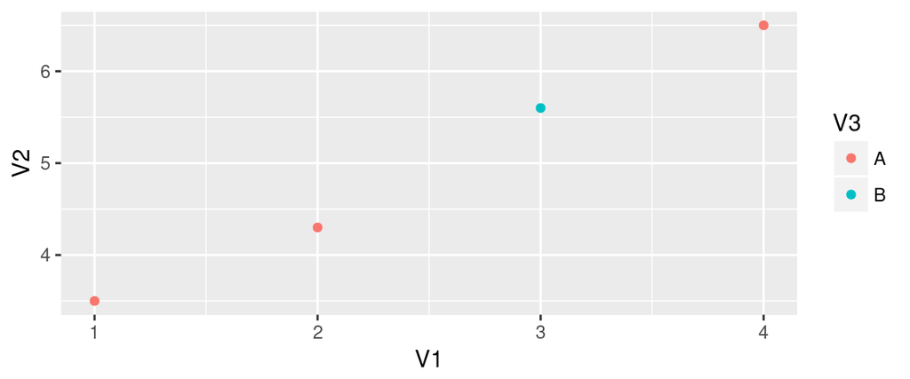

```r
ggplot(data = R, aes(x = V1, y = V2, colour = V3)) +
  geom_point()
```

#### layers - stats

**stat**istical transformations: Stats fassen Daten je nach Bedarf zusammen - z.B. kann man mit ihnen einen Spline einpassen oder die Häufigkeit des Auftretens für ein Histogramm zählen

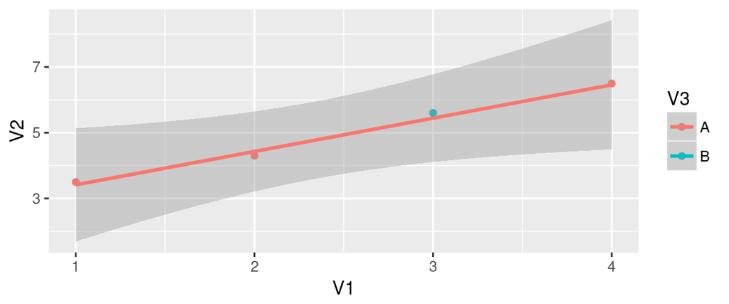

```r
ggplot(data = R, aes(x = V1, y = V2, colour = V3)) +
  geom_point() +
  stat_smooth(method = "lm")
```

#### layers - stats

**stat**istical transformations: Stats fassen Daten je nach Bedarf zusammen - z.B. kann man mit ihnen einen Spline einpassen oder die Häufigkeit des Auftretens für ein Histogramm zählen

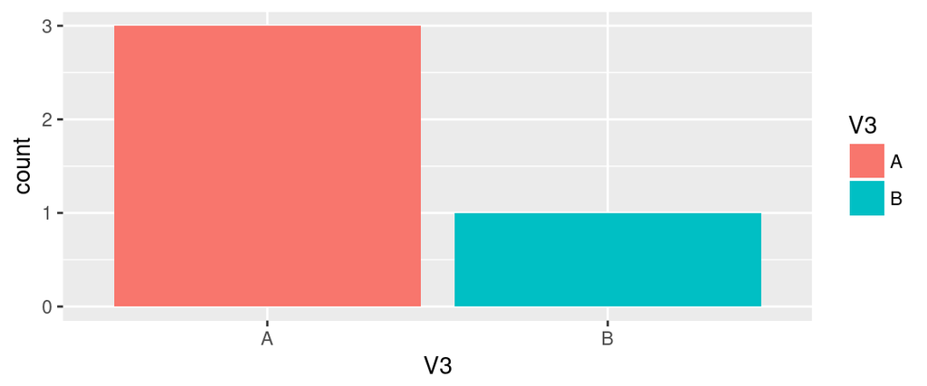

```r
ggplot(data = R, aes(x = V3, fill = V3)) +
  geom_bar(stat = "count")
```

#### scales

**scales**: Spezifizierung der Zuordnung von Daten zu grafischer Veranschaulichung (data -> aes). Scales steuert auch Legenden und Achsenskalierung

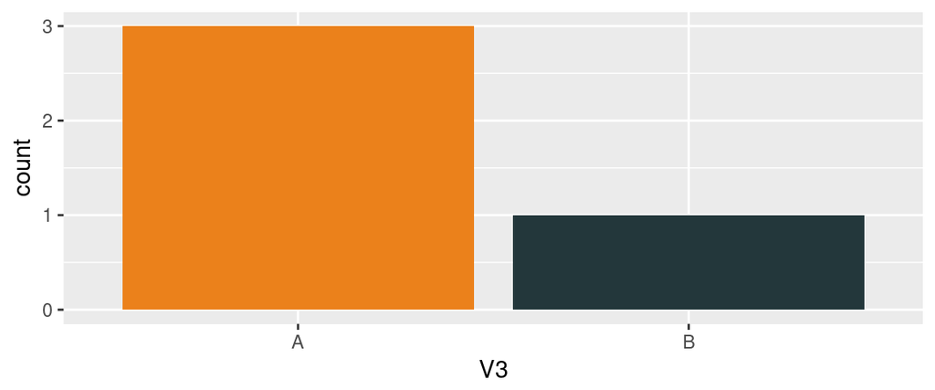

```r
ggplot(data = R, aes(x = V3, fill = V3)) +
  geom_bar(stat = "count") +
  scale_fill_manual(
    values = c('A' = '#EB811B', 'B' = '#23373B'),
    guide = FALSE
  )
```

#### faceting

**faceting**: Aufteilen von Daten nach Kategorien (subsets) und getrennte Visualisierung der Kategorien

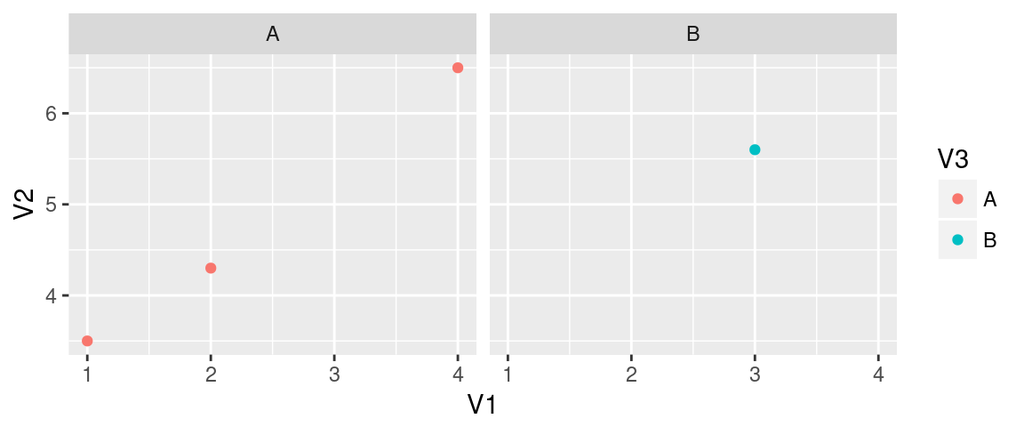

```r
ggplot(data = R, aes(x = V1, y = V2, colour = V3)) +
  geom_point() +
  facet_wrap(~V3)
```

#### theme

**theme**: Steuerung der nicht oder nicht unmittelbar datenbezogenen, visuellen Qualitäten eines Plots - z.B. Hintergrundfarbe, Gridlines, Titel, Beschriftungen

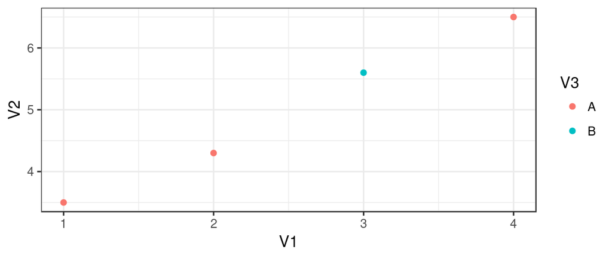

```r
ggplot(data = R, aes(x = V1, y = V2, colour = V3)) +
  geom_point() +
  theme_bw()
```

#### theme

**theme**: Steuerung der nicht oder nicht unmittelbar datenbezogenen, visuellen Qualitäten eines Plots - z.B. Hintergrundfarbe, Gridlines, Titel, Beschriftungen

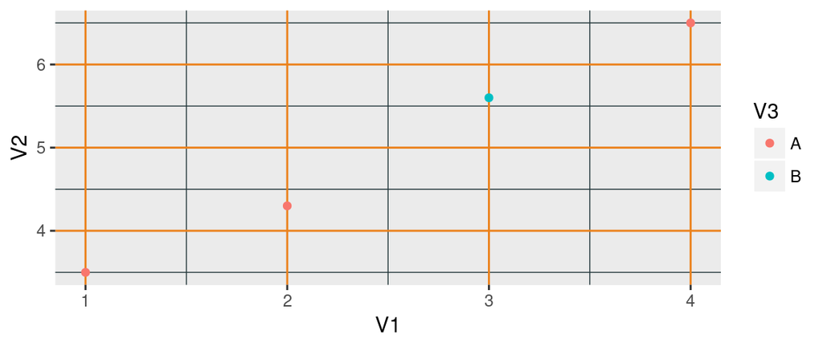

```r
ggplot(data = R, aes(x = V1, y = V2, colour = V3)) +
  geom_point() +
  theme(
    panel.grid.minor = element_line(colour = '#23373B'),
    panel.grid.major = element_line(colour = '#EB811B')
  )
```

#### coord

**coord**inate system: Beschreibt, wie Koordinaten auf die Plotfläche projiziert werden und stellt Achsen und Gridlines bereit. Neben dem normalen Karthesischen Koordinatenysstem stehen z.B. auch geographische Koordinatensysteme zur Verfügung

```r
library(maps)
```

```r
world <- map_data("world")

worldmap <- ggplot(world, aes(x = long, y = lat, group = group)) +
  geom_polygon(fill = "white", colour = "black") +
  coord_map("ortho", orientation = c(48, 9, 0))

worldmap +
  geom_point(aes(x = 10, y = 53.33), colour = "red", size = 7)
```

#### coord

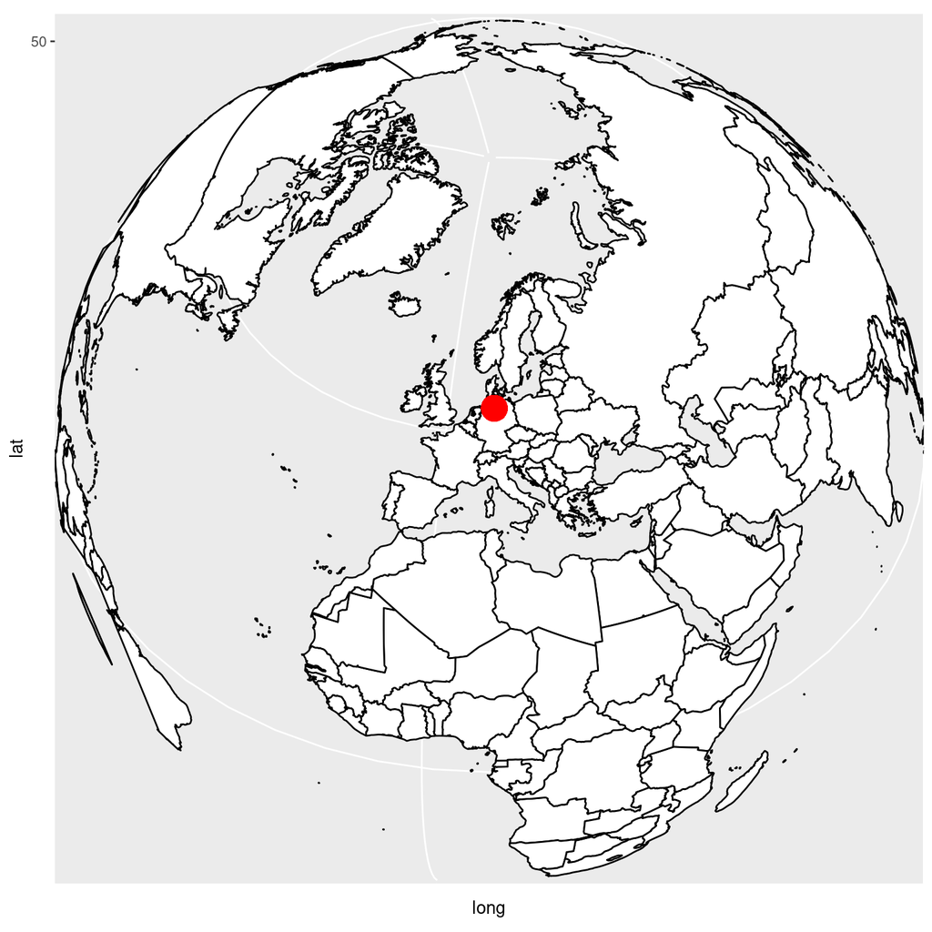

#### Zusammenfassung

**data**: Ausgangsdaten  
**aes**: Zuweisung Variablen -> Visualisierung. Spezifizierung mit **scales**  
**geom**: Plottyp/Elemente  
**stats**: Zusammenfassungsoperationen  
**faceting**: Mehrere Teilplots erstellen  
**theme**: Plotlayout/Design  
**coord**: Koordinatensystem

- ggplot(**data**, **aes**()) +
  - **geom**_…() +
  - **geom**_…(**aes**(), **stat**) +
  - **scale**_…_…() +
  - **facet**_…(~) +
  - **theme**_…() +
  - **coord**_…()

## Quellen und Empfehlungen

#### Weblinks und Literatur

**Web**

- http://ggplot2.org/ - ggplot-Homepage
- https://github.com/hadley/ggplot2 - Github-Repository zu ggplot2
- http://docs.ggplot2.org/current/index.html - Online Dokumentation und Hilfe
- http://had.co.nz/ - Hadley Wickhams Homepage

**Literatur**

- W. Chang, R graphics cookbook: practical recipes for visualizing data (Sebastopol 2013)
- H. Wickham, ggplot2: elegant graphics for data analysis (New York 2009) und neuere Versionen des Buchs (https://github.com/hadley/ggplot2-book)
- L. Wilkinson/G. Wills, The grammar of graphics (New York 2005)